# Project 6: Randomization and Matching

2024-04-03

# Introduction

In this project, you will explore the question of whether college education causally affects political participation. Specifically, you will use replication data from {https://papers.ssrn.com/sol3/papers.cfm?abstract_id=1409483}{Who Matches? Propensity Scores and Bias in the Causal Eﬀects of Education on Participation} by former Berkeley PhD students John Henderson and Sara Chatfield. Their paper is itself a replication study of {https://www.jstor.org/stable/10.1017/s0022381608080651}{Reconsidering the Effects of Education on Political Participation} by Cindy Kam and Carl Palmer. In their original 2008 study, Kam and Palmer argue that college education has no effect on later political participation, and use the propensity score matching to show that pre-college political activity drives selection into college and later political participation. Henderson and Chatfield in their 2011 paper argue that the use of the propensity score matching in this context is inappropriate because of the bias that arises from small changes in the choice of variables used to model the propensity score. They use {http://sekhon.berkeley.edu/papers/GenMatch.pdf}{genetic matching} (at that point a new method), which uses an approach similar to optimal matching to optimize Mahalanobis distance weights. Even with genetic matching, they find that balance remains elusive however, thus leaving open the question of whether education causes political participation.

You will use these data and debates to investigate the benefits and pitfalls associated with matching methods. Replication code for these papers is available online, but as you’ll see, a lot has changed in the last decade or so of data science! Throughout the assignment, use tools we introduced in lab from the {https://www.tidyverse.org/}{tidyverse} and the {https://cran.r-project.org/web/packages/MatchIt/MatchIt.pdf}{MatchIt} packages. Specifically, try to use dplyr, tidyr, purrr, stringr, and ggplot instead of base R functions. While there are other matching software libraries available, MatchIt tends to be the most up to date and allows for consistent syntax.

# Data

The data is drawn from the {https://www.icpsr.umich.edu/web/ICPSR/studies/4023/datadocumentation#}{Youth-Parent Socialization Panel Study} which asked students and parents a variety of questions about their political participation. This survey was conducted in several waves. The first wave was in 1965 and established the baseline pre-treatment covariates. The treatment is whether the student attended college between 1965 and 1973 (the time when the next survey wave was administered). The outcome is an index that calculates the number of political activities the student engaged in after 1965. Specifically, the key variables in this study are:

```
 college: Treatment of whether the student attended college or not. 1 if the student attended college between 1965 and 1973, 0 otherwise.
```

ppnscal: Outcome variable measuring the number of political activities the student participated in. Additive combination of whether the student voted in 1972 or 1980 (student_vote), attended a campaign rally or meeting (student_meeting), wore a campaign button (student_button), donated money to a campaign (student_money), communicated with an elected official (student_communicate), attended a demonstration or protest (student_demonstrate), was involved with a local community event (student_community), or some other political participation (student_other)

Otherwise, we also have covariates measured for survey responses to various questions about political attitudes. We have covariates measured for the students in the baseline year, covariates for their parents in the baseline year, and covariates from follow-up surveys.{Be careful here}. In general, post-treatment covariates will be clear from the name (i.e. student_1973Married indicates whether the student was married in the 1973 survey). Be mindful that the baseline covariates were all measured in 1965, the treatment occurred between 1965 and 1973, and the outcomes are from 1973 and beyond. We will distribute the Appendix from Henderson and Chatfield that describes the covariates they used, but please reach out with any questions if you have questions about what a particular variable means.

```r
# Load tidyverse and MatchIt
# Feel free to load other libraries as you wish
library(tidyverse)
library(MatchIt)
library(dplyr)
library(cobalt)
library(tinytex)
library(parallel)
library(gridExtra)
```

```r
library(ggplot2)
library(purrr)
library(pbapply)


# Load ypsps data
ypsps <- read_csv('data/ypsps.csv')
head(ypsps)
```

```
## # A tibble: 6 × 174
##   interviewid college student_vote student_meeting student_other student_button
##         <dbl>   <dbl>        <dbl>           <dbl>         <dbl>          <dbl>
## 1           1       1            1               0             0              0
## 2           2       1            1               1             1              1
## 3           3       1            1               0             0              1
## 4           4       0            0               0             0              0
## 5           5       1            1               1             0              0
## 6           6       1            1               0             0              0
## # ℹ 168 more variables: student_money <dbl>, student_communicate <dbl>,
## #   student_demonstrate <dbl>, student_community <dbl>, student_ppnscal <dbl>,
## #   student_PubAff <dbl>, student_Newspaper <dbl>, student_Radio <dbl>,
## #   student_TV <dbl>, student_Magazine <dbl>, student_FamTalk <dbl>,
## #   student_FrTalk <dbl>, student_AdultTalk <dbl>, student_PID <dbl>,
## #   student_SPID <dbl>, student_GovtOpinion <dbl>, student_GovtCrook <dbl>,
## #   student_GovtWaste <dbl>, student_TrGovt <dbl>, student_GovtSmart <dbl>, …
```

# Randomization

Matching is usually used in observational studies to to approximate random assignment to treatment. But could it be useful even in randomized studies? To explore the question do the following:

```
 Generate a vector that randomly assigns each unit to either treatment or control
 Choose a baseline covariate (for either the student or parent). A binary covariate is probably best for this exercise.
 Visualize the distribution of the covariate by treatment/control condition. Are treatment and control balanced on this covariate?
 Simulate the first 3 steps 10,000 times and visualize the distribution of treatment/control balance across the simulations.
```

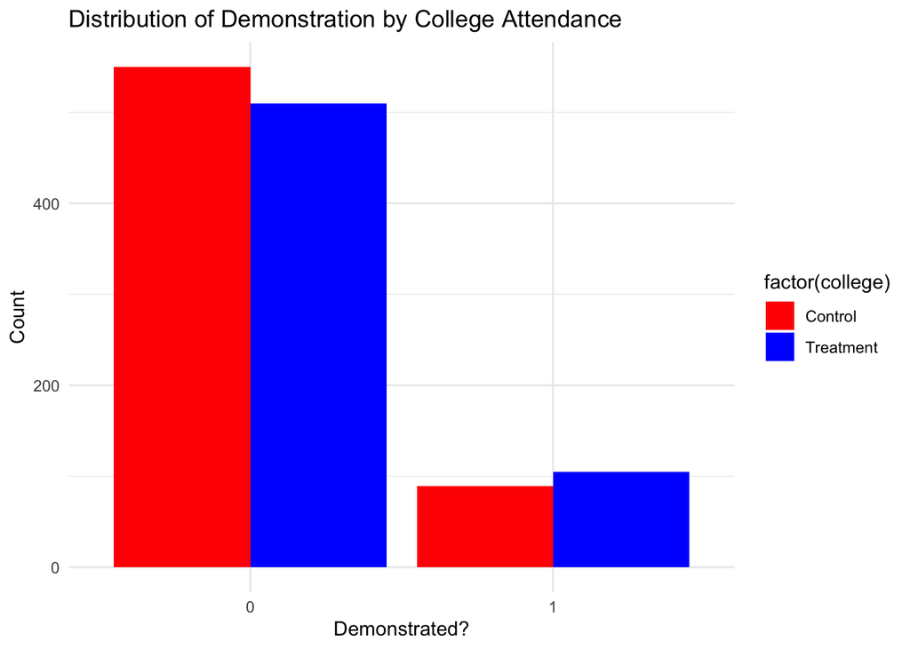

```r
set.seed(42) # Set a seed for reproducibility

ypsps <- ypsps %>%
  mutate(college = sample(c(1, 0), nrow(ypsps), replace = TRUE))


ggplot(ypsps, aes(x = factor(student_demonstrate), fill = factor(college))) +
  geom_bar(position = "dodge") +
  scale_fill_manual(values = c("0" = "red", "1" = "blue"),
                    labels = c("0" = "Control", "1" = "Treatment")) +
  labs(title = "Distribution of Demonstration by College Attendance",
       x = "Demonstrated?",
       y = "Count") +
  theme_minimal()
```

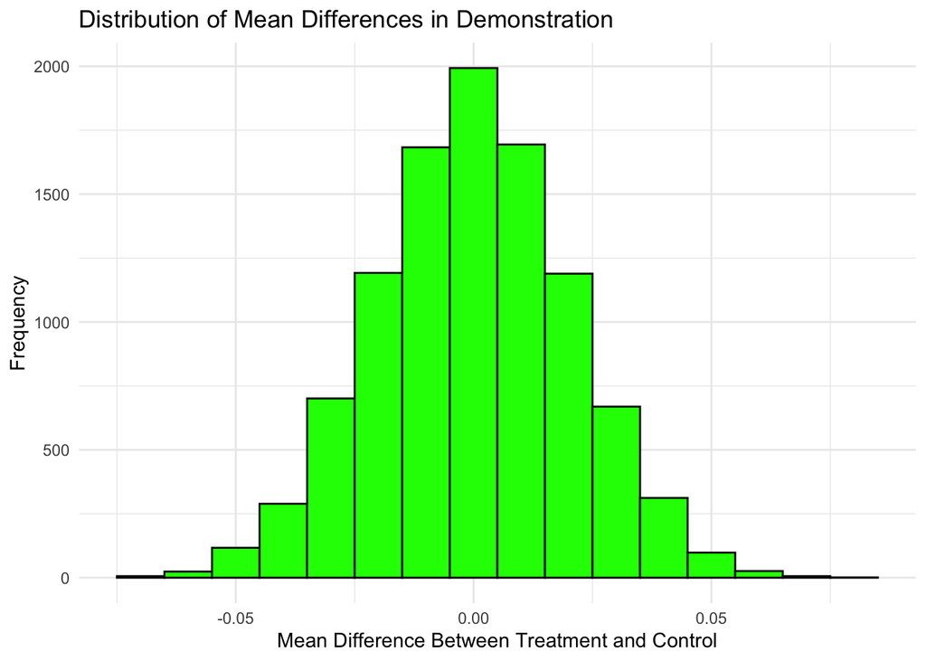

```r
# Simulate this 10,000 times (monte carlo simulation - see R Refresher for a hint)

simulate_diff <- function(data) {
  data_sample <- data %>%
    mutate(college = sample(c(0, 1), n(), replace = TRUE)) %>% # Randomly reassign treatment/control
    group_by(college) %>%
    summarise(mean_demonstrate = mean(student_demonstrate, na.rm = TRUE)) %>%
    ungroup()

  diff <- diff(data_sample$mean_demonstrate)
  return(diff)
}

set.seed(123)
simulations <- replicate(10000, simulate_diff(ypsps), simplify = TRUE)


ggplot(data.frame(MeanDifferences = simulations), aes(x = MeanDifferences)) +
  geom_histogram(binwidth = 0.01, fill = "green", color = "black") +
  labs(title = "Distribution of Mean Differences in Demonstration",
       x = "Mean Difference Between Treatment and Control",
       y = "Frequency") +
  theme_minimal()
```

## Questions

What do you see across your simulations? Why does independence of treatment assignment and baseline covariates not guarantee balance of treatment assignment and baseline covariates?

Your Answer: The distribution of mean differences between my treatment and control groups appear to follow a normal distribution around zero, which means that the random assignment process does not systematically favor one group over the other in terms of whether or not student’s demonstrated. There are several reasons why independence of treatment assignment and baseline covariates does not guarantee balance of treatment assignment and baseline covariates. First, if the baseline covariate has an asymmetric distribution, even with independence, the random allocation could result in imbalances. For example, if a covariate is highly skewed, random sampling may not adequately balance this covariate across groups without specific stratification techniques. Additionally, in any given sample, random assignment can lead to different distributions of covariates. With a large enough sample size, the law of large numbers suggests that the groups will become more balanced on covariates, but in smaller samples, the randomness can create noticeable imbalances.

# Propensity Score Matching

## One Model

Select covariates that you think best represent the “true” model predicting whether a student chooses to attend college, and estimate a propensity score model to calculate the Average Treatment Effect on the Treated (ATT). Plot the balance of the top 10 (or fewer if you select fewer covariates). Report the balance of the p-scores across both the treatment and control groups, and using a threshold of standardized mean difference of p-score $\leq .1$, report the number of covariates that meet that balance threshold.

```r
covariate_names <- c("student_GovtSmart", "student_SchOfficer", "student_Govt4All",
                     "student_TrGovt", "student_Cynic", "student_PubAff",
                     "student_demonstrate", "student_Gen", "student_Race",
                     "parent_Vote")


## Fit logistic regression model for propensity score estimation
ps_model <- glm(college ~ student_GovtSmart + student_SchOfficer + student_Govt4All +
                student_TrGovt + student_Cynic + student_PubAff +
                student_demonstrate + student_Gen + student_Race +
                parent_Vote,
                family = binomial(link = "logit"), data = ypsps)
ypsps$propensity_score <- predict(ps_model, type = "response")

#matchit_model <- matchit(college ~ student_GovtSmart + student_SchOfficer + student_Govt4All +
#                         student_TrGovt + student_Cynic + student_PubAff +
#                         student_demonstrate + student_Gen + student_Race +
#                         parent_Vote,
#                         method = "nearest", data = ypsps,
#                         distance = "propensity_score")

matchit_model <- matchit(college ~ student_GovtSmart + student_SchOfficer + student_Govt4All +
                         student_TrGovt + student_Cynic + student_PubAff +
                         student_demonstrate + student_Gen + student_Race +
                         parent_Vote,
                         method = "full",distance = "mahalanobis", data = ypsps,estimand = "ATE")

matchit_model
```

```
## A matchit object
##  - method: Optimal full matching
##  - distance: Mahalanobis
##  - number of obs.: 1254 (original), 1254 (matched)
##  - target estimand: ATE
##  - covariates: student_GovtSmart, student_SchOfficer, student_Govt4All, student_TrGovt, student_Cynic, student_PubAff, student_demonstrate, student_Gen, student_Race, parent_Vote
```

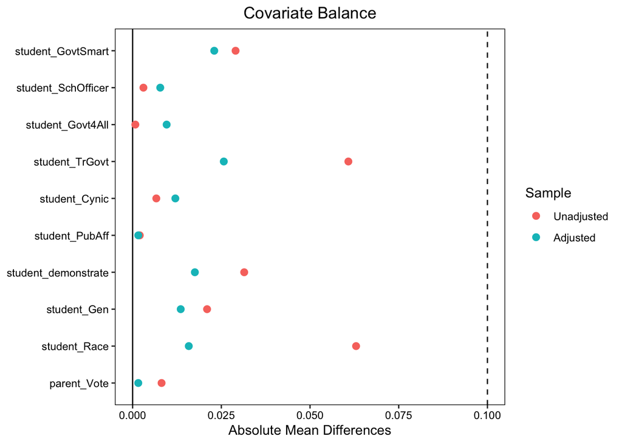

```r
#plot(matchit_model, var.order = "unmatched")

# Plot the balance for the top 10 covariates
love.plot(matchit_model,stats = c("m"), abs = TRUE,thresholds = c(m = .1,v=2))
```

```r
bal.tab(matchit_model, un = TRUE, stats = c("m", "v", "ks"))
```

```
## Balance Measures
##                        Type Diff.Un V.Ratio.Un  KS.Un Diff.Adj V.Ratio.Adj
## student_GovtSmart   Contin. -0.0290     0.9490 0.0121  -0.0230      0.9629
## student_SchOfficer  Contin.  0.0030     1.0598 0.0225  -0.0078      1.0361
## student_Govt4All    Contin.  0.0008     0.9844 0.0034  -0.0096      1.0213
## student_TrGovt      Contin.  0.0608     1.0802 0.0206   0.0257      1.0381
## student_Cynic       Contin. -0.0067     1.0433 0.0209  -0.0120      0.9777
## student_PubAff       Binary -0.0020          . 0.0020   0.0016           .
## student_demonstrate  Binary  0.0315          . 0.0315   0.0175           .
## student_Gen          Binary  0.0210          . 0.0210  -0.0136           .
## student_Race        Contin. -0.0630     0.8455 0.0193  -0.0158      0.9578
## parent_Vote          Binary  0.0082          . 0.0082  -0.0016           .
##                     KS.Adj
## student_GovtSmart   0.0104
## student_SchOfficer  0.0153
## student_Govt4All    0.0032
## student_TrGovt      0.0096
## student_Cynic       0.0108
## student_PubAff      0.0016
## student_demonstrate 0.0175
## student_Gen         0.0136
## student_Race        0.0048
## parent_Vote         0.0016
##
## Sample sizes
##                      Control Treated
## All                   639.    615.
## Matched (ESS)         561.45  498.19
## Matched (Unweighted)  639.    615.
```

```r
# View list of the stored information
bal.tab(matchit_model, un = TRUE, stats = c("m", "v", "ks"),thresholds = c(m = .1,v=2)) #%>%
```

```
## Balance Measures
##                        Type Diff.Un V.Ratio.Un  KS.Un Diff.Adj    M.Threshold
## student_GovtSmart   Contin. -0.0290     0.9490 0.0121  -0.0230 Balanced, <0.1
## student_SchOfficer  Contin.  0.0030     1.0598 0.0225  -0.0078 Balanced, <0.1
## student_Govt4All    Contin.  0.0008     0.9844 0.0034  -0.0096 Balanced, <0.1
## student_TrGovt      Contin.  0.0608     1.0802 0.0206   0.0257 Balanced, <0.1
## student_Cynic       Contin. -0.0067     1.0433 0.0209  -0.0120 Balanced, <0.1
## student_PubAff       Binary -0.0020          . 0.0020   0.0016 Balanced, <0.1
## student_demonstrate  Binary  0.0315          . 0.0315   0.0175 Balanced, <0.1
## student_Gen          Binary  0.0210          . 0.0210  -0.0136 Balanced, <0.1
## student_Race        Contin. -0.0630     0.8455 0.0193  -0.0158 Balanced, <0.1
## parent_Vote          Binary  0.0082          . 0.0082  -0.0016 Balanced, <0.1
##                     V.Ratio.Adj  V.Threshold KS.Adj
## student_GovtSmart        0.9629 Balanced, <2 0.0104
## student_SchOfficer       1.0361 Balanced, <2 0.0153
## student_Govt4All         1.0213 Balanced, <2 0.0032
## student_TrGovt           1.0381 Balanced, <2 0.0096
## student_Cynic            0.9777 Balanced, <2 0.0108
## student_PubAff                .              0.0016
## student_demonstrate           .              0.0175
## student_Gen                   .              0.0136
## student_Race             0.9578 Balanced, <2 0.0048
## parent_Vote                   .              0.0016
##
## Balance tally for mean differences
##                    count
## Balanced, <0.1        10
## Not Balanced, >0.1     0
##
## Variable with the greatest mean difference
##        Variable Diff.Adj    M.Threshold
##  student_TrGovt   0.0257 Balanced, <0.1
##
## Balance tally for variance ratios
##                  count
## Balanced, <2         6
## Not Balanced, >2     0
##
## Variable with the greatest variance ratio
##      Variable V.Ratio.Adj  V.Threshold
##  student_Race      0.9578 Balanced, <2
##
## Sample sizes
##                      Control Treated
## All                   639.    615.
## Matched (ESS)         561.45  498.19
## Matched (Unweighted)  639.    615.
```

```r
  #View()
balance_statistics <-
  bal.tab(matchit_model, un = TRUE, stats = c("m", "v", "ks"),thresholds = c(m = .1,v=2)) %>%
  pluck("Balance") %>%
  as_tibble() %>%
  mutate(covariate = covariate_names) #%>%  # Add covariate names as a new column
 # glimpse()


balance_statistics
```

```
## # A tibble: 10 × 10
##    Type      Diff.Un V.Ratio.Un   KS.Un Diff.Adj M.Threshold    V.Ratio.Adj
##    <chr>       <dbl>      <dbl>   <dbl>    <dbl> <chr>                <dbl>
##  1 Contin. -0.0290        0.949 0.0121  -0.0230  Balanced, <0.1       0.963
##  2 Contin.  0.00304       1.06  0.0225  -0.00779 Balanced, <0.1       1.04
##  3 Contin.  0.000769      0.984 0.00337 -0.00959 Balanced, <0.1       1.02
##  4 Contin.  0.0608        1.08  0.0206   0.0257  Balanced, <0.1       1.04
##  5 Contin. -0.00668       1.04  0.0209  -0.0120  Balanced, <0.1       0.978
##  6 Binary  -0.00202      NA     0.00202  0.00159 Balanced, <0.1      NA
##  7 Binary   0.0315       NA     0.0315   0.0175  Balanced, <0.1      NA
##  8 Binary   0.0210       NA     0.0210  -0.0136  Balanced, <0.1      NA
##  9 Contin. -0.0630        0.846 0.0193  -0.0158  Balanced, <0.1       0.958
## 10 Binary   0.00816      NA     0.00816 -0.00159 Balanced, <0.1      NA
## # ℹ 3 more variables: V.Threshold <chr>, KS.Adj <dbl>, covariate <chr>
```

```r
# Report the overall balance and the proportion of covariates that meet the balance threshold

# Define the thresholds
m_threshold <- 0.1  # Diff.Adj threshold
v_threshold <- 0.5 # V.Ratio.Adj threshold

# Calculate proportions for M.Threshold
proportion_m_threshold <- sum(balance_statistics$Diff.Adj <= m_threshold, na.rm = TRUE) / nrow(balance_statistics)

# Calculate proportions for V.Threshold
# Filter out blank rows
non_blank_rows <- balance_statistics %>%
  filter(!is.na(V.Ratio.Adj))

# Calculate proportions for V.Threshold
proportion_v_threshold <- sum(non_blank_rows$V.Ratio.Adj >= v_threshold, na.rm = TRUE) / nrow(non_blank_rows)

# Print the proportions
cat("Proportion of covariates meeting M.Threshold (Diff.Adj <= ", m_threshold, "): ", proportion_m_threshold, "\n")
```

```
## Proportion of covariates meeting M.Threshold (Diff.Adj <=  0.1 ):  1
```

```r
cat("Proportion of covariates meeting V.Threshold (V.Ratio.Adj >= ", v_threshold, "): ", proportion_v_threshold, "\n")
```

```
## Proportion of covariates meeting V.Threshold (V.Ratio.Adj >=  0.5 ):  1
```

They are all balanced.

## Simulations

Henderson/Chatfield argue that an improperly specified propensity score model can actually the bias of the estimate. To demonstrate this, they simulate 800,000 different propensity score models by choosing different permutations of covariates. To investigate their claim, do the following:

```
 Using as many simulations as is feasible (at least 10,000 should be ok, more is better!), randomly select the number of and the choice of covariates for the propensity score model.
 For each run, store the ATT, the proportion of covariates that meet the standardized mean difference $\leq .1$ threshold, and the mean percent improvement in the standardized mean difference. You may also wish to store the entire models in a list and extract the relevant attributes as necessary.
 Plot all of the ATTs against all of the balanced covariate proportions. You may randomly sample or use other techniques like transparency if you run into overplotting problems. Alternatively, you may use plots other than scatterplots, so long as you explore the relationship between ATT and the proportion of covariates that meet the balance threshold.
 Finally choose 10 random models and plot their covariate balance plots (you may want to use a library like {https://cran.r-project.org/web/packages/gridExtra/index.html}{gridExtra} to arrange these)
```

Note: There are lots of post-treatment covariates in this dataset (about 50!)! You need to be careful not to include these in the pre-treatment balancing. Many of you are probably used to selecting or dropping columns manually, or positionally. However, you may not always have a convenient arrangement of columns, nor is it fun to type out 50 different column names. Instead see if you can use dplyr 1.0.0 functions to programatically drop post-treatment variables ({https://www.tidyverse.org/blog/2020/03/dplyr-1-0-0-select-rename-relocate/}{here} is a useful tutorial).

```r
covariate_names <- c("student_GovtSmart", "student_SchOfficer", "student_Govt4All",
                     "student_TrGovt", "student_Cynic", "student_PubAff",
                     "student_demonstrate", "student_Gen", "student_Race",
                     "parent_Vote")


## Fit logistic regression model for propensity score estimation
ps_model <- glm(college ~ student_GovtSmart + student_SchOfficer + student_Govt4All +
                student_TrGovt + student_Cynic + student_PubAff +
                student_demonstrate + student_Gen + student_Race +
                parent_Vote,
                family = binomial(link = "logit"), data = ypsps)
ypsps$propensity_score <- predict(ps_model, type = "response")

#matchit_model <- matchit(college ~ student_GovtSmart + student_SchOfficer + student_Govt4All +
#                         student_TrGovt + student_Cynic + student_PubAff +
#                         student_demonstrate + student_Gen + student_Race +
#                         parent_Vote,
#                         method = "nearest", data = ypsps,
#                         distance = "propensity_score")

matchit_model <- matchit(college ~ student_GovtSmart + student_SchOfficer + student_Govt4All +
                         student_TrGovt + student_Cynic + student_PubAff +
                         student_demonstrate + student_Gen + student_Race +
                         parent_Vote,
                         method = "full",distance = "mahalanobis", data = ypsps,estimand = "ATE")

matchit_model
```

```
## A matchit object
##  - method: Optimal full matching
##  - distance: Mahalanobis
##  - number of obs.: 1254 (original), 1254 (matched)
##  - target estimand: ATE
##  - covariates: student_GovtSmart, student_SchOfficer, student_Govt4All, student_TrGovt, student_Cynic, student_PubAff, student_demonstrate, student_Gen, student_Race, parent_Vote
```

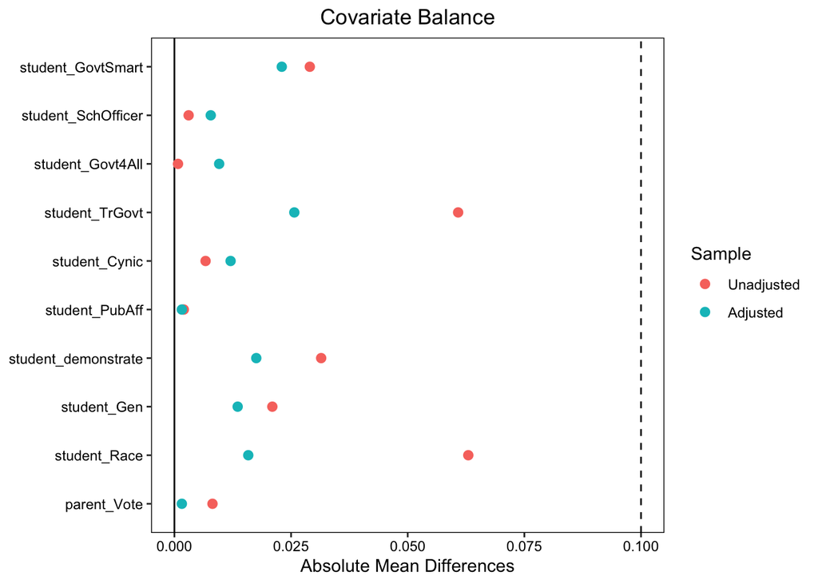

```r
#plot(matchit_model, var.order = "unmatched")

# Plot the balance for the top 10 covariates
love.plot(matchit_model,stats = c("m"), abs = TRUE,thresholds = c(m = .1,v=2))
```

```r
bal.tab(matchit_model, un = TRUE, stats = c("m", "v", "ks"))
```

```
## Balance Measures
##                        Type Diff.Un V.Ratio.Un  KS.Un Diff.Adj V.Ratio.Adj
## student_GovtSmart   Contin. -0.0290     0.9490 0.0121  -0.0230      0.9629
## student_SchOfficer  Contin.  0.0030     1.0598 0.0225  -0.0078      1.0361
## student_Govt4All    Contin.  0.0008     0.9844 0.0034  -0.0096      1.0213
## student_TrGovt      Contin.  0.0608     1.0802 0.0206   0.0257      1.0381
## student_Cynic       Contin. -0.0067     1.0433 0.0209  -0.0120      0.9777
## student_PubAff       Binary -0.0020          . 0.0020   0.0016           .
## student_demonstrate  Binary  0.0315          . 0.0315   0.0175           .
## student_Gen          Binary  0.0210          . 0.0210  -0.0136           .
## student_Race        Contin. -0.0630     0.8455 0.0193  -0.0158      0.9578
## parent_Vote          Binary  0.0082          . 0.0082  -0.0016           .
##                     KS.Adj
## student_GovtSmart   0.0104
## student_SchOfficer  0.0153
## student_Govt4All    0.0032
## student_TrGovt      0.0096
## student_Cynic       0.0108
## student_PubAff      0.0016
## student_demonstrate 0.0175
## student_Gen         0.0136
## student_Race        0.0048
## parent_Vote         0.0016
##
## Sample sizes
##                      Control Treated
## All                   639.    615.
## Matched (ESS)         561.45  498.19
## Matched (Unweighted)  639.    615.
```

```r
# View list of the stored information
bal.tab(matchit_model, un = TRUE, stats = c("m", "v", "ks"),thresholds = c(m = .1,v=2)) #%>%
```

```
## Balance Measures
##                        Type Diff.Un V.Ratio.Un  KS.Un Diff.Adj    M.Threshold
## student_GovtSmart   Contin. -0.0290     0.9490 0.0121  -0.0230 Balanced, <0.1
## student_SchOfficer  Contin.  0.0030     1.0598 0.0225  -0.0078 Balanced, <0.1
## student_Govt4All    Contin.  0.0008     0.9844 0.0034  -0.0096 Balanced, <0.1
## student_TrGovt      Contin.  0.0608     1.0802 0.0206   0.0257 Balanced, <0.1
## student_Cynic       Contin. -0.0067     1.0433 0.0209  -0.0120 Balanced, <0.1
## student_PubAff       Binary -0.0020          . 0.0020   0.0016 Balanced, <0.1
## student_demonstrate  Binary  0.0315          . 0.0315   0.0175 Balanced, <0.1
## student_Gen          Binary  0.0210          . 0.0210  -0.0136 Balanced, <0.1
## student_Race        Contin. -0.0630     0.8455 0.0193  -0.0158 Balanced, <0.1
## parent_Vote          Binary  0.0082          . 0.0082  -0.0016 Balanced, <0.1
##                     V.Ratio.Adj  V.Threshold KS.Adj
## student_GovtSmart        0.9629 Balanced, <2 0.0104
## student_SchOfficer       1.0361 Balanced, <2 0.0153
## student_Govt4All         1.0213 Balanced, <2 0.0032
## student_TrGovt           1.0381 Balanced, <2 0.0096
## student_Cynic            0.9777 Balanced, <2 0.0108
## student_PubAff                .              0.0016
## student_demonstrate           .              0.0175
## student_Gen                   .              0.0136
## student_Race             0.9578 Balanced, <2 0.0048
## parent_Vote                   .              0.0016
##
## Balance tally for mean differences
##                    count
## Balanced, <0.1        10
## Not Balanced, >0.1     0
##
## Variable with the greatest mean difference
##        Variable Diff.Adj    M.Threshold
##  student_TrGovt   0.0257 Balanced, <0.1
##
## Balance tally for variance ratios
##                  count
## Balanced, <2         6
## Not Balanced, >2     0
##
## Variable with the greatest variance ratio
##      Variable V.Ratio.Adj  V.Threshold
##  student_Race      0.9578 Balanced, <2
##
## Sample sizes
##                      Control Treated
## All                   639.    615.
## Matched (ESS)         561.45  498.19
## Matched (Unweighted)  639.    615.
```

```r
  #View()
balance_statistics <-
  bal.tab(matchit_model, un = TRUE, stats = c("m", "v", "ks"),thresholds = c(m = .1,v=2)) %>%
  pluck("Balance") %>%
  as_tibble() %>%
  mutate(covariate = covariate_names) #%>%  # Add covariate names as a new column
 # glimpse()


balance_statistics
```

```
## # A tibble: 10 × 10
##    Type      Diff.Un V.Ratio.Un   KS.Un Diff.Adj M.Threshold    V.Ratio.Adj
##    <chr>       <dbl>      <dbl>   <dbl>    <dbl> <chr>                <dbl>
##  1 Contin. -0.0290        0.949 0.0121  -0.0230  Balanced, <0.1       0.963
##  2 Contin.  0.00304       1.06  0.0225  -0.00779 Balanced, <0.1       1.04
##  3 Contin.  0.000769      0.984 0.00337 -0.00959 Balanced, <0.1       1.02
##  4 Contin.  0.0608        1.08  0.0206   0.0257  Balanced, <0.1       1.04
##  5 Contin. -0.00668       1.04  0.0209  -0.0120  Balanced, <0.1       0.978
##  6 Binary  -0.00202      NA     0.00202  0.00159 Balanced, <0.1      NA
##  7 Binary   0.0315       NA     0.0315   0.0175  Balanced, <0.1      NA
##  8 Binary   0.0210       NA     0.0210  -0.0136  Balanced, <0.1      NA
##  9 Contin. -0.0630        0.846 0.0193  -0.0158  Balanced, <0.1       0.958
## 10 Binary   0.00816      NA     0.00816 -0.00159 Balanced, <0.1      NA
## # ℹ 3 more variables: V.Threshold <chr>, KS.Adj <dbl>, covariate <chr>
```

```r
# Report the overall balance and the proportion of covariates that meet the balance threshold

# Define the thresholds
m_threshold <- 0.1  # Diff.Adj threshold
v_threshold <- 0.5 # V.Ratio.Adj threshold

# Calculate proportions for M.Threshold
proportion_m_threshold <- sum(balance_statistics$Diff.Adj <= m_threshold, na.rm = TRUE) / nrow(balance_statistics)

# Calculate proportions for V.Threshold
# Filter out blank rows
non_blank_rows <- balance_statistics %>%
  filter(!is.na(V.Ratio.Adj))

# Calculate proportions for V.Threshold
proportion_v_threshold <- sum(non_blank_rows$V.Ratio.Adj >= v_threshold, na.rm = TRUE) / nrow(non_blank_rows)

# Print the proportions
cat("Proportion of covariates meeting M.Threshold (Diff.Adj <= ", m_threshold, "): ", proportion_m_threshold, "\n")
```

```
## Proportion of covariates meeting M.Threshold (Diff.Adj <=  0.1 ):  1
```

```r
cat("Proportion of covariates meeting V.Threshold (V.Ratio.Adj >= ", v_threshold, "): ", proportion_v_threshold, "\n")
```

```
## Proportion of covariates meeting V.Threshold (V.Ratio.Adj >=  0.5 ):  1
```

## Simulations

Henderson/Chatfield argue that an improperly specified propensity score model can actually increase the bias of the estimate. To demonstrate this, they simulate 800,000 different propensity score models by choosing different permutations of covariates. To investigate their claim, do the following:

```
Using as many simulations as is feasible (at least 10,000 should be ok, more is better!), randomly select the number of and the choice of covariates for the propensity score model.
```

For each run, store the ATT, the proportion of covariates that meet the standardized mean difference $\leq .1$ threshold, and the mean percent improvement in the standardized mean difference. You may also wish to store the entire models in a list and extract the relevant attributes as necessary. Plot all of the ATTs against all of the balanced covariate proportions. You may randomly sample or use other techniques like transparency if you run into overplotting problems. Alternatively, you may use plots other than scatterplots, so long as you explore the relationship between ATT and the proportion of covariates that meet the balance threshold. Finally choose 10 random models and plot their covariate balance plots (you may want to use a library like {https://cran.r-project.org/web/packages/gridExtra/index.html}{gridExtra} to arrange these)

Note: There are lots of post-treatment covariates in this dataset (about 50!)! You need to be careful not to include these in the pre-treatment balancing. Many of you are probably used to selecting or dropping columns manually, or positionally. However, you may not always have a convenient arrangement of columns, nor is it fun to type out 50 different column names. Instead see if you can use dplyr 1.0.0 functions to programatically drop post-treatment variables {https://www.tidyverse.org/blog/2020/03/dplyr-1-0-0-select-rename-relocate/}{here} is a useful tutorial).

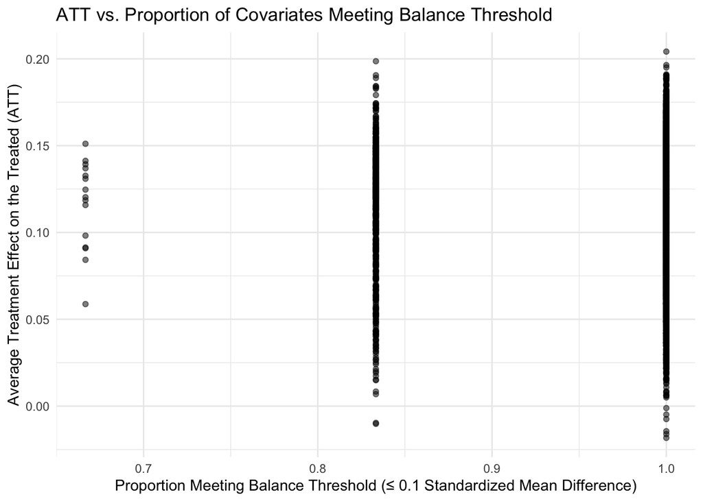

```r
m_threshold <- 0.1
pre_treatment_data <- ypsps %>%
  select(-c('student_1973Married',
 'student_1973Military',
 'student_1973Drafted',
 'student_1973Unemployed',
 'student_1973NoEmployers',
 'student_1973OwnHome',
 'student_1973NoResidences',
 'student_1973VoteNixon',
 'student_1973VoteMcgovern',
 'student_1973CollegeDegree',
 'student_1973CurrentCollege',
 'student_1973CollegeYears',
 'student_1973HelpMinority',
 'student_1973Busing',
 'student_1973GovChange',
 'student_1973VietnamRight',
 'student_1973VietnamApprove',
 'student_1973Trust',
 'student_1973Luck',
 'student_1973SureAboutLife',
 'student_1973CurrentSituation',
 'student_1973FutureSituation',
 'student_1973ThermMilitary',
 'student_1973ThermRadical',
 'student_1973ThermDems',
 'student_1973ThermRep',
 'student_1973ThermBlack',
 'student_1973ThermWhite',
 'student_1973ThermNixon',
 'student_1973ThermMcgovern',
 'student_1973Newspaper',
 'student_1973PubAffairs',
 'student_1973GovtEfficacy',
 'student_1973GovtNoSay',
 'student_1973PartyID',
 'student_1973IncSelf',
 'student_1973HHInc',
 'student_1973ChurchAttend',
 'student_1973Knowledge',
 'student_1973Ideology',
 'student_1982vote76',
 'student_1982vote80',
 'student_1982meeting',
 'student_1982other',
 'student_1982button',
 'student_1982money',
 'student_1982communicate',
 'student_1982demonstrate',
 'student_1982community',
 'student_1982IncSelf',
 'student_1982HHInc',
 'student_1982College',
 "interviewid"))

covariate_names <- c('student_vote',
 'student_meeting',
 'student_other',
 'student_button',
 'student_money',
 'student_communicate',
 'student_demonstrate',
 'student_community',
 'student_PubAff',
 'student_Newspaper',
 'student_Radio',
 'student_TV',
 'student_Magazine',
 'student_FamTalk',
 'student_FrTalk',
 'student_AdultTalk',
 'student_PID',
 'student_SPID',
 'student_GovtOpinion',
 'student_GovtCrook',
 'student_GovtWaste',
 'student_TrGovt',
 'student_GovtSmart',
 'student_Govt4All',
 'student_Cynic',
 'student_LifeWish',
 'student_GLuck',
 'student_FPlans',
 'student_EgoA',
 'student_WinArg',
 'student_StrOpinion',
 'student_MChange',
 'student_EgoB',
 'student_TrOthers',
 'student_OthHelp',
 'student_OthFair',
 'student_Trust',
 'student_Senate',
 'student_Tito',
 'student_Court',
 'student_Govern',
 'student_CCamp',
 'student_FDR',
 'student_Knowledge',
 'student_NextSch',
 'student_GPA',
 'student_SchOfficer',
 'student_SchPublish',
 'student_Hobby',
 'student_SchClub',
 'student_OccClub',
 'student_NeighClub',
 'student_RelClub',
 'student_YouthOrg',
 'student_MiscClub',
 'student_ClubLev',
 'student_Phone',
 'student_Gen',
 'student_Race',
 'parent_Newspaper',
 'parent_Radio',
 'parent_TV',
 'parent_Magazine',
 'parent_LifeWish',
 'parent_GLuck',
 'parent_FPlans',
 'parent_WinArg',
 'parent_StrOpinion',
 'parent_MChange',
 'parent_TrOthers',
 'parent_OthHelp',
 'parent_OthFair',
 'parent_PID',
 'parent_SPID',
 'parent_Vote',
 'parent_Persuade',
 'parent_Rally',
 'parent_OthAct',
 'parent_PolClub',
 'parent_Button',
 'parent_Money',
 'parent_Participate1',
 'parent_Participate2',
 'parent_ActFrq',
 'parent_GovtOpinion',
 'parent_GovtCrook',
 'parent_GovtWaste',
 'parent_TrGovt',
 'parent_GovtSmart',
 'parent_Govt4All',
 'parent_Employ',
 'parent_EducHH',
 'parent_EducW',
 'parent_ChurchOrg',
 'parent_FratOrg',
 'parent_ProOrg',
 'parent_CivicOrg',
 'parent_CLOrg',
 'parent_NeighClub',
 'parent_SportClub',
 'parent_InfClub',
 'parent_FarmGr',
 'parent_WomenClub',
 'parent_MiscClub',
 'parent_ClubLev',
 'parent_FInc',
 'parent_HHInc',
 'parent_OwnHome',
 'parent_Senate',
 'parent_Tito',
 'parent_Court',
 'parent_Govern',
 'parent_CCamp',
 'parent_FDR',
 'parent_Knowledge',
 'parent_Gen',
 'parent_Race')
simulate_model <- function(data, covariate_names) {
  selected_covariates <- sample(covariate_names, 5)

  formula1 <- as.formula(paste("college ~", paste(selected_covariates, collapse = " + ")))
  formula2 <- as.formula(paste('student_ppnscal ~ college +', paste(selected_covariates, collapse = " + ")))

  ps_model <- glm(formula1, family = binomial(link = "logit"), data = data, na.action = na.exclude)
  data$propensity_score <- predict(ps_model, type = "response")

  matchit_model <- matchit(formula1, method = "nearest", data = data, distance = "glm", estimand = "ATT", thresholds = c(m = .1, v = 2))

  balance <- bal.tab(matchit_model, un = TRUE, stats = c("m", "v", "ks")) %>% pluck("Balance") %>% as_tibble()

  matchit_data <- match.data(matchit_model)
  attform <- summary(lm(formula2, data = matchit_data, weights = weights))

  improvement <- (balance$Diff.Un - balance$Diff.Adj) / balance$Diff.Un * 100

  att <- attform$coefficients["college", "Estimate"]
  proportion_meeting_threshold <- sum(balance$Diff.Adj <= m_threshold, na.rm = TRUE) / nrow(balance)
  mean_percent_improvement <- mean(improvement, na.rm = TRUE)

  list(att = att, proportion_meeting_threshold = proportion_meeting_threshold, mean_percent_improvement = mean_percent_improvement, matchit_model = matchit_model)
}

library(pbapply)

# Running Simulations with a Progress Bar
set.seed(123)
n_simulations <- 7000
results <- pblapply(1:n_simulations, function(x) simulate_model(pre_treatment_data, covariate_names))




# Running Simulations
#set.seed(123)
#n_simulations <- 10000
#results <- lapply(1:n_simulations, function(x) simulate_model(pre_treatment_data, covariate_names))

# Data Extraction for Visualization
simulation_data <- data.frame(
  simulation = 1:n_simulations,
  att = sapply(results, `[[`, "att"),
  proportion_meeting_threshold = sapply(results, `[[`, "proportion_meeting_threshold"),
  mean_percent_improvement = sapply(results, `[[`, "mean_percent_improvement")
)


 ggplot(simulation_data, aes(x = proportion_meeting_threshold, y = att)) +
  geom_point(alpha = 0.5) +  # Adjust alpha for overplotting if necessary
  labs(title = "ATT vs. Proportion of Covariates Meeting Balance Threshold",
       x = "Proportion Meeting Balance Threshold (≤ 0.1 Standardized Mean Difference)",
       y = "Average Treatment Effect on the Treated (ATT)") +
  theme_minimal()
```

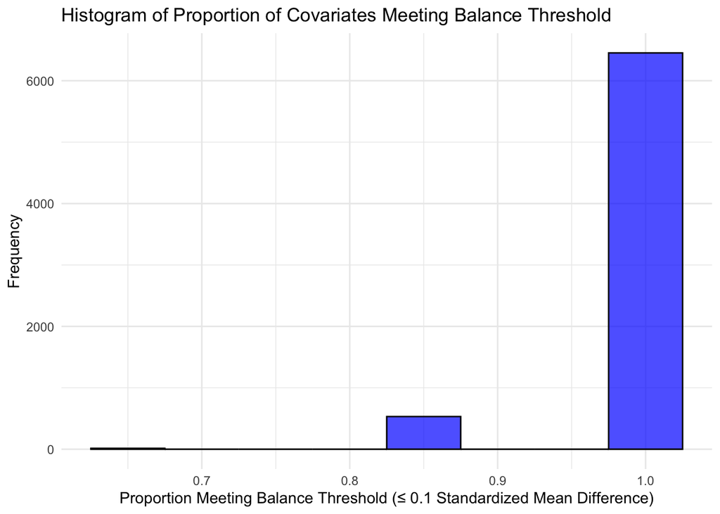

```r
# Group by 'proportion_meeting_threshold', then calculate mean ATT for each group
mean_att_by_proportion <- simulation_data %>%
  group_by(proportion_meeting_threshold) %>%
  summarize(mean_att = mean(att, na.rm = TRUE))  # na.rm = TRUE to remove NA values if any



# Histogram for the proportion_meeting_threshold
ggplot(simulation_data, aes(x = proportion_meeting_threshold)) +
  geom_histogram(binwidth = 0.05, fill = "blue", color = "black", alpha = 0.7) +
  labs(title = "Histogram of Proportion of Covariates Meeting Balance Threshold",
       x = "Proportion Meeting Balance Threshold (≤ 0.1 Standardized Mean Difference)",
       y = "Frequency") +
  theme_minimal()
```

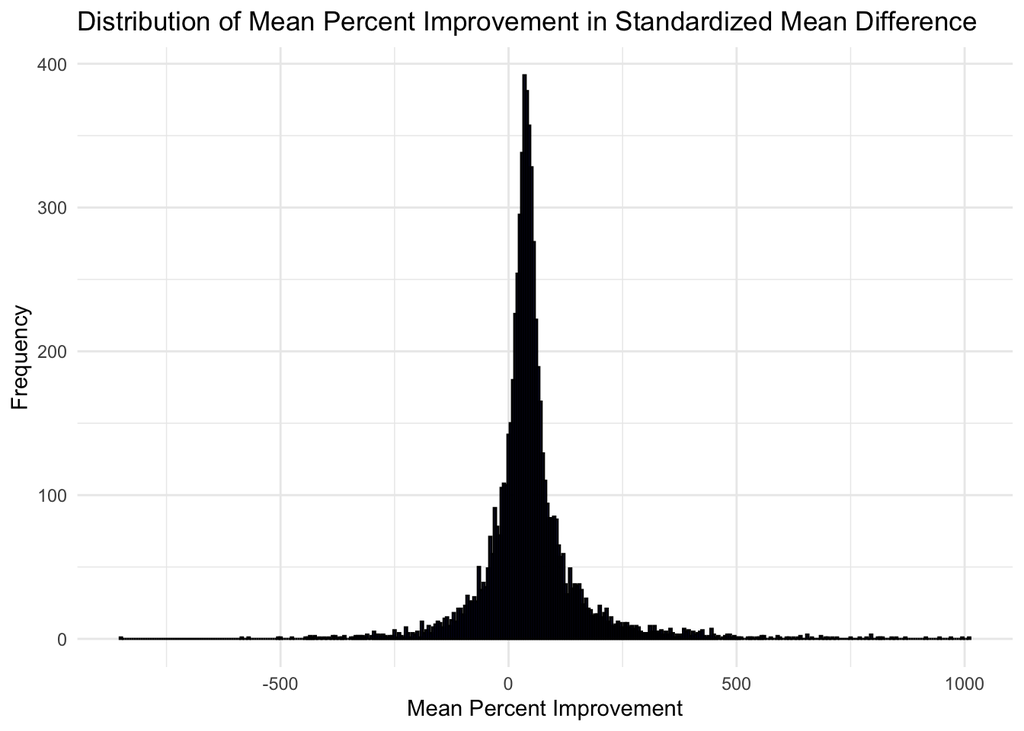

```r
# Plotting the distribution of mean percent improvement using a histogram
ggplot(simulation_data, aes(x = mean_percent_improvement)) +
  geom_histogram(binwidth = 5, fill = "blue", color = "black", alpha = 0.7) +  # Adjust binwidth as needed
  labs(title = "Distribution of Mean Percent Improvement in Standardized Mean Difference",
       x = "Mean Percent Improvement",
       y = "Frequency") +
  theme_minimal()
```

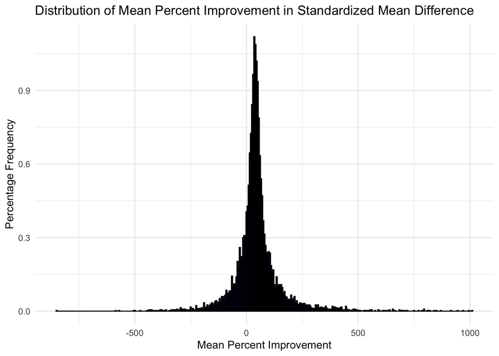

```r
# Plotting the percentage frequency distribution of mean percent improvement
ggplot(simulation_data, aes(x = mean_percent_improvement)) +
  geom_histogram(aes(y = ..density.. * 100), binwidth = 5, fill = "blue", color = "black", alpha = 0.7) +  # Adjust binwidth as needed
  labs(title = "Distribution of Mean Percent Improvement in Standardized Mean Difference",
       x = "Mean Percent Improvement",
       y = "Percentage Frequency") +
  theme_minimal()
```

[figure not shown]

```r
set.seed(123) # Ensures reproducibility
selected_indices <- sample(seq_along(results), 10, replace = FALSE)
selected_models <- results[selected_indices]

# Generate Love plots for the selected models
plots <- lapply(selected_models, function(model) {
  # Extract the MatchIt model from the list
  matchit_model <- model$matchit_model

  # Generate a Love plot for each selected model
  love.plot(matchit_model,
            threshold = 0.1,
            abs = TRUE,
            title = "Covariate Balance Plot")
})
do.call(grid.arrange, c(plots, ncol = 2))
```

```r
# Define the threshold
threshold <- 0

# Count the number of simulations where the proportion of balanced covariates exceeds the threshold
num_simulations_above_threshold <- sum(simulation_data$mean_percent_improvement > threshold)

# Calculate the proportion of simulations above the threshold
proportion_above_threshold <- num_simulations_above_threshold / nrow(simulation_data)

num_simulations_above_threshold
```

```
## [1] 5552
```

```r
proportion_above_threshold
```

```
## [1] 0.7931429
```

## Questions

How many simulations resulted in models with a higher proportion of balanced covariates? Do you have any concerns about this?

Your Answer: 79% of simulations had models had a higher proportion of balanced covariates.

Analyze the distribution of the ATTs. Do you have any concerns about this distribution?

Do your 10 randomly chosen covariate balance plots produce similar numbers on the same covariates? Is it a concern if they do not?

# Matching Algorithm of Your Choice

## Simulate Alternative Model

Henderson/Chatfield propose using genetic matching to learn the best weights for Mahalanobis distance matching. Choose a matching algorithm other than the propensity score (you may use genetic matching if you wish, but it is also fine to use the greedy or optimal algorithms we covered in lab instead). Repeat the same steps as specified in Section 4.2 and answer the following questions:

```r
simulate_model <- function(data, covariate_names) {

  selected_covariates <- sample(covariate_names, 5)

  formula1 <- as.formula(paste("college ~", paste(selected_covariates, collapse = " + ")))
  formula2 <- as.formula(paste('student_ppnscal ~ college +',paste(selected_covariates, collapse = " + ")))
ps_model <- glm(formula1, family = binomial(link = "logit"), data = data, na.action = na.exclude)
  data$propensity_score <- predict(ps_model, type = "response")

  matchit_model3 <- matchit(formula1, method = "genetic", data = data, estimand = "ATT",pop.size = 2)

  balance <- bal.tab(matchit_model3, un = TRUE, stats = c("m", "v", "ks")) %>%
  pluck("Balance") %>%
  as_tibble()

  matchit_data = match.data(matchit_model3)
 attform <- summary(lm(formula2, data = matchit_data,weight=weights))
  balance_before <- bal.tab(matchit_model3, un = TRUE, stats = c("m", "v", "ks"), match.on = FALSE)

  balance_after <- bal.tab(matchit_model3, un = TRUE, stats = c("m", "v", "ks"), match.on = TRUE)

  improvement = (balance$Diff.Un - balance$Diff.Adj) / balance$Diff.Un * 100

  att <- attform$coefficients["college", "Estimate"]
proportion_meeting_threshold <- sum(balance$Diff.Adj <= m_threshold, na.rm = TRUE) / nrow(balance)
  mean_percent_improvement = mean(improvement, na.rm = TRUE)

  list(att = att, proportion_meeting_threshold = proportion_meeting_threshold,
       mean_percent_improvement = mean_percent_improvement, matchit_model3 = matchit_model3)}
set.seed(123)
n_simulations <- 2000
seeds <- sample.int(10000, n_simulations, replace = TRUE)

results <- pblapply(seeds, function(seed) simulate_model(pre_treatment_data, covariate_names))
```

```r
# Data extraction for visualization
simulation_data2 <- data.frame(
  simulation = 1:length(results),
  att = sapply(results, function(x) x$att),
  proportion_meeting_threshold = sapply(results, function(x) ifelse("proportion_meeting_threshold" %in% names(x), x$proportion_meeting_threshold, NA)),
  mean_percent_improvement = sapply(results, function(x) ifelse("mean_percent_improvement" %in% names(x), x$mean_percent_improvement, NA))
)


# Calculate the percentage of mean_percent_improvement values greater than 0
percentage_greater_than_zero <- mean(simulation_data2$mean_percent_improvement > 0)
percentage_greater_than_zero
```

```
## [1] 0.436
```

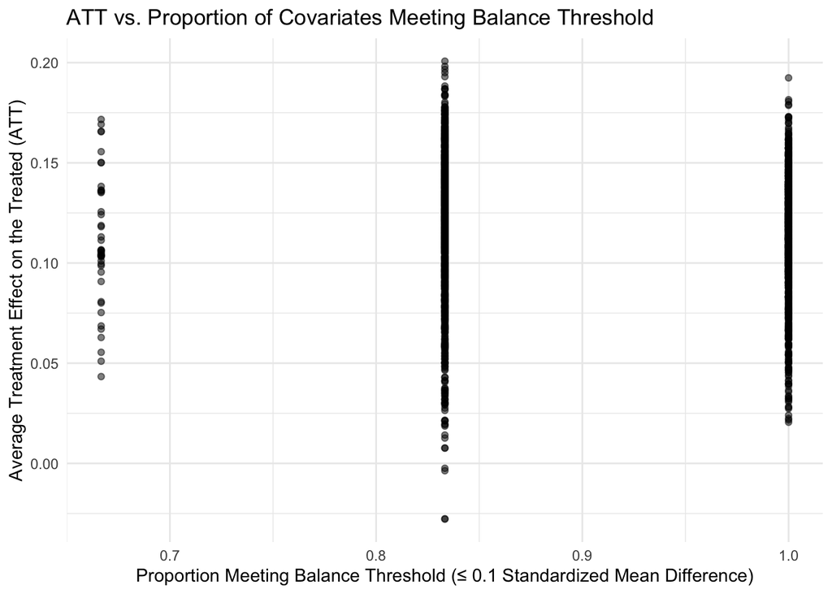

```r
# Visualization
ggplot(simulation_data2, aes(x = proportion_meeting_threshold, y = att)) +
  geom_point(alpha = 0.5) +
  labs(title = "ATT vs. Proportion of Covariates Meeting Balance Threshold",
       x = "Proportion Meeting Balance Threshold (≤ 0.1 Standardized Mean Difference)",
       y = "Average Treatment Effect on the Treated (ATT)") +
  theme_minimal()
```

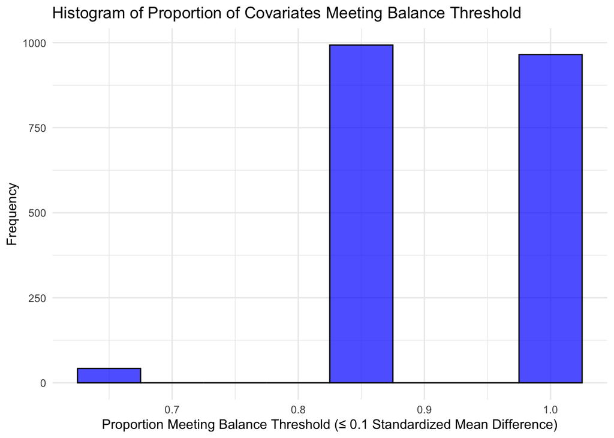

```r
# Histogram of Proportion Meeting Threshold
ggplot(simulation_data2, aes(x = proportion_meeting_threshold)) +
  geom_histogram(binwidth = 0.05, fill = "blue", color = "black", alpha = 0.7) +
  labs(title = "Histogram of Proportion of Covariates Meeting Balance Threshold",
       x = "Proportion Meeting Balance Threshold (≤ 0.1 Standardized Mean Difference)",
       y = "Frequency") +
  theme_minimal()
```

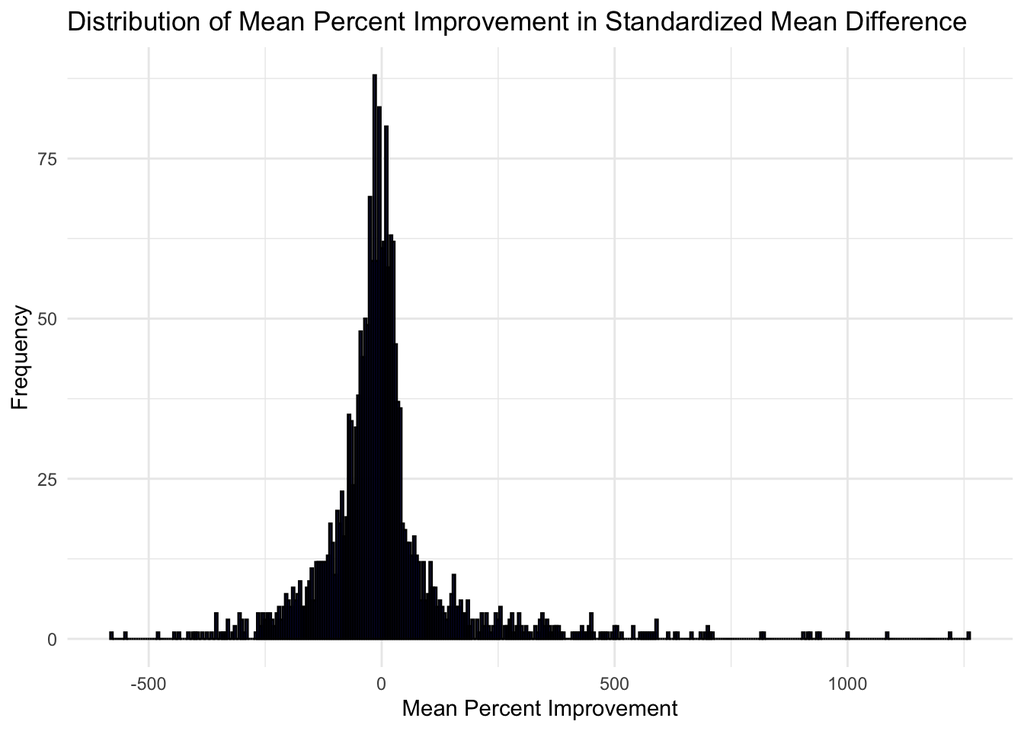

```r
# Distribution of Mean Percent Improvement
ggplot(simulation_data2, aes(x = mean_percent_improvement)) +
  geom_histogram(binwidth = 5, fill = "blue", color = "black", alpha = 0.7) +
  labs(title = "Distribution of Mean Percent Improvement in Standardized Mean Difference",
       x = "Mean Percent Improvement",
       y = "Frequency") +
  theme_minimal()
```

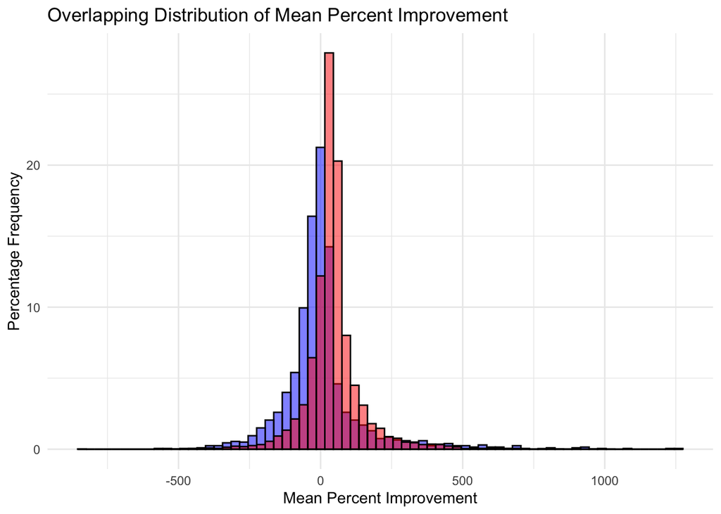

```r
ggplot() +
  geom_histogram(data = simulation_data2, aes(x = mean_percent_improvement, y = ..count../sum(..count..) * 100),
                 binwidth = 30, fill = "blue", color = "black", alpha = 0.5) +
  geom_histogram(data = simulation_data, aes(x = mean_percent_improvement, y = ..count../sum(..count..) * 100),
                 binwidth = 30, fill = "red", color = "black", alpha = 0.5) +
  labs(title = "Overlapping Distribution of Mean Percent Improvement",
       x = "Mean Percent Improvement",
       y = "Percentage Frequency") +
  theme_minimal()
```

## Questions

Does your alternative matching method have more runs with higher proportions of balanced covariates?

Your Answer: Definitely not. The low population hyperparameter likely didn’t help.

Use a visualization to examine the change in the distribution of the percent improvement in balance in propensity score matching vs. the distribution of the percent improvement in balance in your new method. Which did better? Analyze the results in 1-2 sentences.

Your Answer: The propensity score model outperformed the genetic matching algorithm. Again, I needed to set the population size hyperparameter extremely low to get this to run as many simulations as it did (and it still timed out overnight), so that didn’t help. Also, it is worth mentioning that I was able to run 5,000 simulations on RStudio R Markdown file (compared with the 2000 simulations on here), but my memory would time out when generating the HTLM document. Increasing the number of simulations did not help balance the covariates.

Looking ahead to the discussion questions, you may choose to model the propensity score using an algorithm other than logistic regression and perform these simulations again, if you wish to explore the second discussion question further.

# Discussion Questions

Why might it be a good idea to do matching even if we have a randomized or as-if-random design?

Your Answer: Matching is a good idea even in randomized or as-if-random designs for several reasons. First, in cases where sample sizes are small, randomization might not guarantee perfect balance across groups due to chance. Matching can help achieve balance and ensure that the most comparable units are being compared, which is particularly crucial when the sample size cannot be easily increased. Second, matching can help in reducing variability within treatment and control groups by ensuring that the matched units are similar in terms of observed covariates. In this case, matching can improve model precision. Lastly, in as-if random designs, matching can help validate the presumed randomness by ensuring that units just above or below the cutoff on whether or not the subject recieves the treatment are similar on other dimensions.

The standard way of estimating the propensity score is using a logistic regression to estimate probability of treatment. Given what we know about the curse of dimensionality, do you think there might be advantages to using other machine learning algorithms (decision trees, bagging/boosting forests, ensembles, etc.) to estimate propensity scores instead?}

Your Answer: If you’re asking, I’m sure there are advantages to using other machine learning algorithms to estimate propensity scores. First, machine learning algorithms can handle non-linear relationships without transforming or modifying variables. In other words, machine learning algorithms provide accurate non-linear propensity score estimations without manual adjustments. Second, techniques like feature selection and regularization can effectively identify and focus on the most relevant predictors for treatment assignment, which can help reduce or mitigate the curse of dimensionality associated with gnerating propensity scores using linear models. Lastly, ensemble methods enhance propensity score estimation by combining estimates from multiple models, thereby improving accuracy and generalization. This aggregated approach leads to more precise and robust predictions of treatment probabilities, crucial for minimizing bias in observational studies.